# Analysis of ARMOUR Residential REIT (ARR) excess returns in the period 2016-2020

Alessandro Salmaso 863820

8/26/2021

## Introduction

The aim of this paper is to analyze the excess returns of ARMOUR Residential REIT, Inc. (ARR ticker), in the period January 2016-December 2020, using the R software.  
In particular, the focus of this research is to display how to use the R code to perform a correct analysis of the returns.  
The company chosen is a small cap, value firm. The market capitalization is equal to 872.536M and the P/E ratio equals 5.44.

In the first part it is explained how to import the dataset and how to perform a descriptive analysis of the data, an ARIMA model is fitted.  
In the second part the Single-Index model and the Fama-French Three-Factor model are fitted into the data with the OLS regression approach and a diagnostic of the residuals is performed at the end.  
We want to establish if the Fama-French model can capture the extra-market risk exposure of the company and can explain better than the single-index model the firm’s excess returns variability.

The single-index model implies a regression of ARMOUR’s excess returns on the market excesss returns, while the Fama-French model implies a regression of ARMOUR’s excess returns on the market excess returns and on the SMB and HML proxies.

Let’s look at the relevant variables that are going to be used inside this paper:  
- R_ARR: the ARMOUR REIT’s excess returns (simple returns - risk free rate = excess returns);  
- R_MKT: the market excess returns. Given that it’s impossible to observe the true market portfolio, a proxy is used instead;  
- SMB (Small-Minus-Big): this is a proxy for some extra-market risk factors that are difficult to be observed. In particular, it’s ‘the return of a portfolio of small stocks in excess of the return on a portfolio of large stocks’ (Bodie, Kane, Marcus - Investments);  
- HML (High-Minus-Low): another extra-market risk proxy. In this case it’s ‘the return of a portfolio of stocks with a high book-to-market ratio in excess of the return on a portfolio of stocks with a low book-to-market ratio’ (Bodie, Kane, Marcus - Investments).  
The analyzed period is January 2016 – December 2020 and all the data are monthly.

A detailed description of how the variables R_MKT, HML and SMB are built can be found directly in the Kenneth French Data Library https://mba.tuck.dartmouth.edu/pages/faculty/ken.french/data_library.html, where they are downloaded.  
R_ARR, ARMOUR’s excess returns, are computed in an excel spreadsheet from prices downloaded in the yahoo finance website. It will be presented how to compute the returns from prices with R too.

## Data retreiving, cleaning and descriptive analysis

#### Packages loading

The following packages are going to be used and must be loaded with the ‘*library*’ function before proceeding.  
If they aren’t installed in your system, use the function *install.packages( )* to do it.

```r
library(xts)
library(quantmod)
library(readxl)
library(aTSA)
library(forecast)
library(normtest)
library(lmtest)
library(car)
library(nlme)
library(ggthemes)
library(gridExtra)
```

We are using the tidyverse too.

```r
library(tidyverse)
```

Simply speaking, tidyverse is a bundle of packages which allow to perform some procedures inside R with a slightly different code syntax. It may reveal very useful to code some operations that are cumbersome to be coded with R ‘base’.  
In particular, the packages from the tidyverse ggplot2, tibble, purrr and dplyr are going to be used.

#### Data retreiving and cleaning

The data is inside two external documents that are called ‘F-F.csv’ and ‘ARR.xlsx’.  
The first one is a comma-separated values (.csv) file in which the variables R_MKT, SMB and HML are stored. It is downloaded directly from the Professor Kenneth French data library.  
The second one is a Microsoft Excel file (.xlsx) which includes the company stock price, the simple returns and the excess returns. We are interested only in the excess returns (R_ARR).

The function ‘*read.table*’ is useful to import data from .csv documents.  
The dataset to be imported in R must be in your active working directory.

```r
riskfactors <- read.table('F-F.csv', sep=',', dec='.', header=TRUE,
                                         row.names = 1, encoding='UTF-8',
                                                 na.strings='')
```

Type ‘?read.table’ in the console to access the help page of the function and the complete argument descriptions.  
In this case the field separator is the comma and the decimal separator is the dot.  
The missing values are coded with blank spaces (*na.strings*), the first row is a header (a row with variable names) and the first column includes row names.  
The encoding is specified too (*encoding=‘UTF-8’*).

The function *read_excel* can be used to import the excel spreadsheet. The reference package is *readxl*.

```r
returns <- read_excel('ARR.xlsx', col_types=c('date',
                                rep('numeric', times=5)),
                                         col_names=TRUE, na='')
```

The missing values are coded again with blank spaces (na=’ ’) and even if the column type is guessed by default but it’s better specify it. In this case the first column contains dates, the other five numerical variables.  
The *col_names* argument equals the *header* argument of the *read.table* function.

The summary of the dataframes just imported can be obtained with the *summary* function.

```r
summary(returns)
```

```
##       Date                      AdjCloseARR      ARRsimpleRet
##  Min.   :2015-12-01 00:00:00   Min.   : 6.807   Min.   :-0.508559
##  1st Qu.:2017-03-08 18:00:00   1st Qu.:11.639   1st Qu.:-0.021888
##  Median :2018-06-16 00:00:00   Median :14.237   Median : 0.015802
##  Mean   :2018-06-16 15:29:01   Mean   :13.568   Mean   : 0.003467
##  3rd Qu.:2019-09-23 12:00:00   3rd Qu.:16.033   3rd Qu.: 0.044706
##  Max.   :2021-01-01 00:00:00   Max.   :17.751   Max.   : 0.199234
##                                                 NA's   :1
##  ARRsimpleRet(perc)    RF(perc)       ARRexcessRet(perc)
##  Min.   :-50.8558   Min.   :0.00000   Min.   :-50.9759
##  1st Qu.: -2.1888   1st Qu.:0.02000   1st Qu.: -2.3788
##  Median :  1.5802   Median :0.09000   Median :  1.5602
##  Mean   :  0.3467   Mean   :0.08787   Mean   :  0.2589
##  3rd Qu.:  4.4706   3rd Qu.:0.15000   3rd Qu.:  4.4326
##  Max.   : 19.9234   Max.   :0.21000   Max.   : 19.9134
##  NA's   :1          NA's   :1         NA's   :1
```

```r
summary(riskfactors)
```

```
##      Mkt.RF             SMB               HML
##  Min.   :-13.380   Min.   :-5.0300   Min.   :-13.9600
##  1st Qu.: -0.030   1st Qu.:-1.9500   1st Qu.: -2.3100
##  Median :  1.430   Median : 0.2400   Median : -1.2300
##  Mean   :  1.267   Mean   : 0.2569   Mean   : -0.7015
##  3rd Qu.:  3.440   3rd Qu.: 2.0400   3rd Qu.:  1.1100
##  Max.   : 13.650   Max.   : 7.1900   Max.   :  8.2200
##  NA's   :1         NA's   :1         NA's   :1
```

The *window* function allows instead to assign the dataframe variables to single objects.

```r
R_ARR <- window(returns$`ARRexcessRet(perc)`)
R_MKT <- window(riskfactors$Mkt.RF)
SMB <- window(riskfactors$SMB)
HML <- window(riskfactors$HML)
date <- window(returns$Date)
```

We assigned a specific object for each of the variables of interest plus an object with the dates, that will be useful later.

The objects just created are numerical vectors but it’s better to work with time series when analyzing returns or prices.  
When there is the necessity to convert a numerical vector into a time series object, two different paths can be followed: to use the *ts* function from the basic package *stats* or to use the *xts* function, from the *xts* package. The latter produces an object of class *zoo* (look at the *zoo* package) while the first produces a ‘basic’ *ts* class object.  
Now we are converting our numerical vectors in *ts* class objects, later we will deal with *zoo* class objects and the *xts* function.

```r
R_ARR <- ts(R_ARR, start=c(2015, 12), end=c(2021, 1), frequency = 12)
R_MKT <- ts(R_MKT, start=c(2015, 12), end=c(2021, 1), frequency = 12)
SMB <- ts(SMB, start=c(2015, 12), end=c(2021, 1), frequency = 12)
HML <- ts(HML, start=c(2015, 12), end=c(2021, 1), frequency = 12)
```

As it is displayed, the *ts* function requires that the time interval of the observations is specified.

```r
mode(R_ARR)
class(R_ARR)
```

```
## [1] "numeric"
## [1] "ts"
```

The R_ARR object is still numeric in mode, but the class is ‘ts’, ‘time-series’ now.

The code below is useful to find how much missing values there are in each series.

```r
which(is.na(R_ARR))
```

```
## [1] 1
```

```r
which(is.na(R_MKT))
```

```
## [1] 1
```

```r
which(is.na(SMB))
```

```
## [1] 1
```

```r
which(is.na(HML))
```

```
## [1] 1
```

In this case, given that the number of observations is low, you can type in the console the name of each variable and find where the NA is located. Each variable has a NA in Dec 2015.

The function *getSymbols* from the *quantmod* package allows to download directly in R the data from the internet and to assign it to an R object (automatically or not, it depends on the *auto.assign* argument value). The code below illustrates how to download the adjusted closing prices of ARMOUR from yahoo finance. Then, the excess returns are computed.

```r
data.quant<- getSymbols(Symbols='ARR', src='yahoo',
                        verbose=T, auto.assign = F) # daily data
data.quant<- to.monthly(data.quant) # monthly data
p.ARR.quant <- window(data.quant$data.quant.Adjusted) # adjusted
# monthly closing prices

p.ARR.quant <- p.ARR.quant['2015-12/2021-01'] # select only the analyzed period
# Dec 2015 - Jan 2021

R.ARR.quant <- ROC(p.ARR.quant, type='discrete')*100 # simple returns

RF.rate <- window(returns$`RF(perc)`)
RF.rate <- xts(RF.rate, order.by=date, frequency=12) # rf rate as xts obj

R.ARR.quant <- R.ARR.quant - RF.rate
colnames(R.ARR.quant) <- 'ARRexcRet'
# ARR excess returns from Dec 2015 to Jan 2021
```

The ticker of ARMOUR is ‘ARR’ and must be specified inside *getSymbols*. The function downloads daily price observations (open, close, adj close, volume, high, low).  
We need monthly data and then the *to.monthly* function is useful here.  
Consider that the data downloaded includes different variables, but we need only the adjusted monthly closing prices. Once an object with monthly adjusted closing prices is obtained (p.ARR.quant) it must be subsetted according to the analysis period.  
Then, with the *ROC* function, simple returns can be easily computed and once the risk free rate is subtracted the excess returns are obtained (R.ARR.quant object).

```r
mode(R.ARR.quant)
class(R.ARR.quant)
```

```
## [1] "numeric"
## [1] "xts" "zoo"
```

R.ARR.quant is an object of ‘numeric’ mode and ‘zoo’ (‘xts’) class. When stock prices are downloaded with *getSymbols*, a ‘zoo’ class object is returned automatically.

#### Descriptive analysis

We will use the objects imported from external datasets: R_ARR (ARMOUR’s excess returns), R_MKT (market excess returns), SMB and HML.

Let’s start coding a plot which depicts the ARMOUR’s excess returns and the market excess returns.

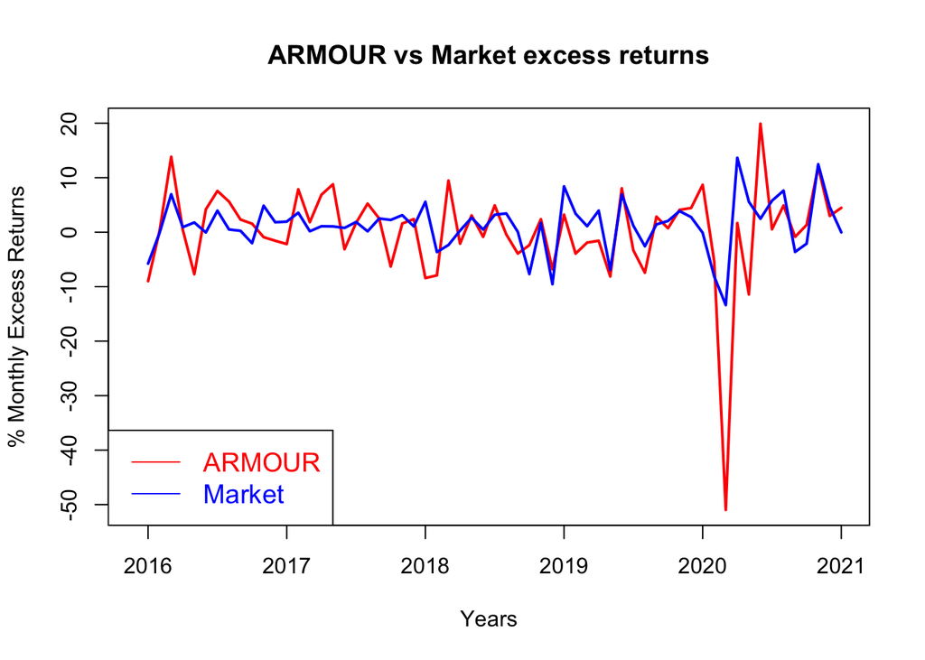

```r
ts.plot(R_ARR, R_MKT, col=c('red', 'blue'), lty=c(1,1), lwd=c(2,2),
                                   main='ARMOUR vs Market excess returns',
                        xlab='Years', ylab='% Monthly Excess Returns')

legend('bottomleft', legend=c('ARMOUR', 'Market'), lty = c(1,1),
            cex=c(1.2), col=c('red', 'blue'), text.col=c('red', 'blue'))
```

*ts.plot* and *legend* are two R ‘base’ functions. The first one is a high level plotting function which creates a new plot, the second one is a low level plotting function which modifies the plot just created, in this case adding a legend.  
We will see later other examples of high level and low level plotting functions, and we will see that there is a package of the Tidyverse, ggplot2, which allows to procuce plots whith a different code syntax based on layers.

An important thing to remember here is to respect the order of the variables inside the code: if R_ARR is the first variable to be plotted, then all the arguments must specify for first the characteristics of the R_ARR plot. If you want it to be red, then ‘red’ must be the first color inside *col=c(‘red’, ‘blue’)* and so on.  
Note that you can tune the dimension of the legend with *cex*.

From this plot it can be observed that ARMOUR’s returns are far more volatile than the market, as can be expected. In particular there is a volatility cluster in the first semester of 2020, during the COVID-19 pandemic outbreak. A whopping negative peak of -50.97 is registered in March 2020, followed by increasing returns in the following months.

```r
summary(R_ARR)
```

```
##     Min.  1st Qu.   Median     Mean  3rd Qu.     Max.     NA's
## -50.9759  -2.3788   1.5602   0.2589   4.4326  19.9134        1
```

```r
summary(R_MKT)
```

```
##    Min. 1st Qu.  Median    Mean 3rd Qu.    Max.    NA's
## -13.380  -0.030   1.430   1.267   3.440  13.650       1
```

The *summary* function can be very useful to evaluate numerical objects like these. It provides different statistics, including the number of NA’s (only 1 in ths case).  
*Summary* is a generic R function: this means that the output depends on the object type. Before, *summary* has been used to check quickly the structure of a dataframe class object, and the output was different.

The mean excess return in the analyzed period is 0.2589 for ARMOUR while the same statistic takes a value of 1.267 for the market instead, a far greater value. It’s clear and not surprising that the COVID-19 pandemic has had a stronger impact on ARMOUR’s returns with respect to the market portfolio.

##### Autocorrelation structure

It’s important to understand the autocorrelation structure of the time series used in the analysis. The functions *acf* and *pacf* are useful for this purpose: the first one computes the autocorrelation function and the second one the partial ACF.

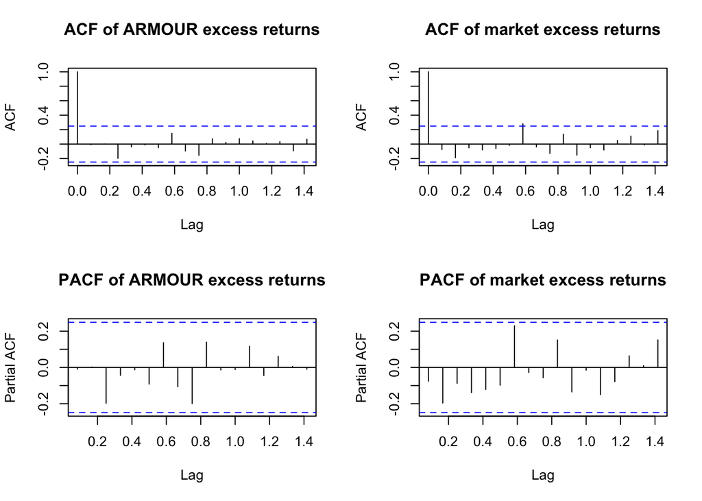

```r
par(mfrow=(c(2,2)))
acf(R_ARR, na.action=na.pass, main='ACF of ARMOUR excess returns')
acf(R_MKT, na.action=na.pass, main='ACF of market excess returns')
pacf(R_ARR, na.action=na.pass, main= 'PACF of ARMOUR excess returns')
pacf(R_MKT, na.action=na.pass, main='PACF of market excess returns')
```

```r
par(mfrow=c(1,1))
```

To display the ACF and the PACF of R_ARR and R_MKT in the same plot it’s necessary to divide the figure region in four parts and to assign to each part one plot. This can be done with *par(mfrow=c(2,2))*: it divides the figure region in a 2x2 matrix.  
*par(mfrow=c(1,1))* it’s needed to reset the figure region.  
*na.pass* is an argument needed to deal with missing values (NA’s).

Both series, market excess returns and ARMOUR’s excess returns, are not autocorrelated or partially autocorrelated.

##### Stationarity

To check for the sationarity of the time series, instead, it’s useful to run the ADF test (Augmented Dickey-Fuller Test).

```r
adf.test(R_ARR)
```

```
## Augmented Dickey-Fuller Test
## alternative: stationary
##
## Type 1: no drift no trend
##      lag   ADF p.value
## [1,]   0 -7.80    0.01
## [2,]   1 -5.34    0.01
## [3,]   2 -5.22    0.01
## [4,]   3 -4.35    0.01
## Type 2: with drift no trend
##      lag   ADF p.value
## [1,]   0 -7.74    0.01
## [2,]   1 -5.31    0.01
## [3,]   2 -5.18    0.01
## [4,]   3 -4.31    0.01
## Type 3: with drift and trend
##      lag   ADF p.value
## [1,]   0 -7.78    0.01
## [2,]   1 -5.37    0.01
## [3,]   2 -5.20    0.01
## [4,]   3 -4.39    0.01
## ----
## Note: in fact, p.value = 0.01 means p.value <= 0.01
```

alpha level=0.05 : H0 is rejected, the series R_ARR is stationary.

```r
adf.test(R_MKT)
```

```
## Augmented Dickey-Fuller Test
## alternative: stationary
##
## Type 1: no drift no trend
##      lag   ADF p.value
## [1,]   0 -7.73    0.01
## [2,]   1 -5.92    0.01
## [3,]   2 -4.31    0.01
## [4,]   3 -3.67    0.01
## Type 2: with drift no trend
##      lag   ADF p.value
## [1,]   0 -8.38    0.01
## [2,]   1 -6.84    0.01
## [3,]   2 -5.25    0.01
## [4,]   3 -4.81    0.01
## Type 3: with drift and trend
##      lag   ADF p.value
## [1,]   0 -8.31    0.01
## [2,]   1 -6.79    0.01
## [3,]   2 -5.22    0.01
## [4,]   3 -4.78    0.01
## ----
## Note: in fact, p.value = 0.01 means p.value <= 0.01
```

alpha level=0.05 : H0 is rejected, the series R_MKT is stationary.

##### Arima fitting

An ARIMA model can be fitted into R_ARR (ARMOUR’s excess returns) and into R_MKT (excess returns of the market). Given that both series are stationary and not autocorrelted, it’s expected a ‘white noise like’ behavior from them.  
The *auto.arima* function from the package *forecast* can be used to automatically fit an ARIMA class model into the data, according to an information criterion.

```r
arima_fit_ARR <- auto.arima(R_ARR)
arima_fit_MKT <- auto.arima(R_MKT)
```

To see the results, use *summary*.

```r
summary(arima_fit_ARR)
```

```
## Series: R_ARR
## ARIMA(0,0,0) with zero mean
##
## sigma^2 estimated as 78.4:  log likelihood=-219.59
## AIC=441.18   AICc=441.25   BIC=443.29
##
## Training set error measures:
##                     ME     RMSE      MAE      MPE     MAPE      MASE
## Training set 0.2588535 8.854541 5.460131 103.8031 292.0942 0.7632746
##                      ACF1
## Training set -0.009560143
```

```r
summary(arima_fit_MKT)
```

```
## Series: R_MKT
## ARIMA(0,0,0) with non-zero mean
##
## Coefficients:
##         mean
##       1.2666
## s.e.  0.5910
##
## sigma^2 estimated as 21.66:  log likelihood=-179.85
## AIC=363.7   AICc=363.91   BIC=367.92
##
## Training set error measures:
##                        ME     RMSE      MAE       MPE     MAPE      MASE
## Training set -7.93946e-13 4.615482 3.178253 -322.0714 735.2476 0.6389519
##                   ACF1
## Training set -0.075752
```

R_ARR is a white noise.  
R_MKT is an ARIMA(0,0,0) with non-zero mean.

Remember always to check the residuals after estimating any model.

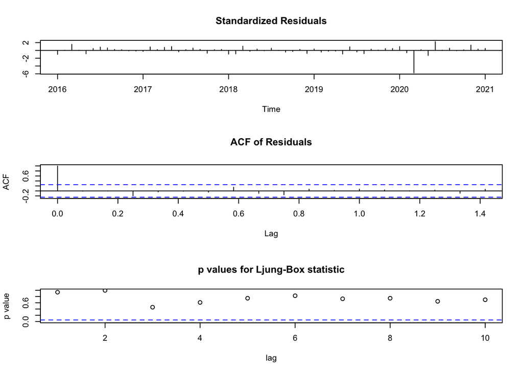

```r
tsdiag(arima_fit_ARR)
```

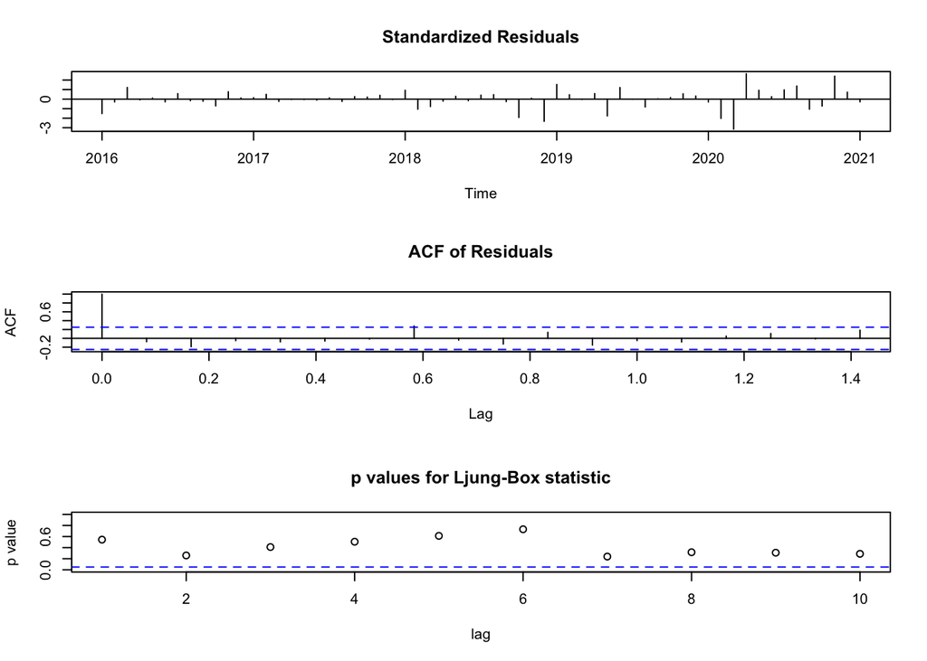

```r
tsdiag(arima_fit_MKT)
```

Both models fit the data well.

## Regression analysis: Single-Index and Fama-French models

There are four assumptions behind the OLS regression to be checked:  
1. Linear relationship between the regressand and each of the regressors  
2. Independence of the residuals (check if they are autocorrelated)  
3. Homoskedasticity of the residuals  
4. Normality of the residuals

A good starting point is to check the normality of the regressand, R_ARR (ARMOUR’s excess returns). Then, we will check graphically the linear relationship between the regressand and each of the regressors.

#### Check the normality of R_ARR series

A histogram helps to understand the probability density shape of the distribution.

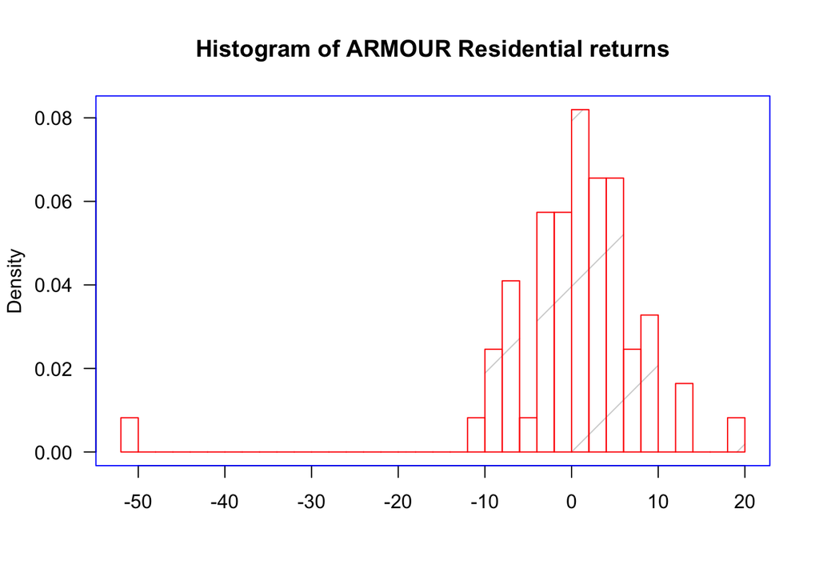

```r
hist(R_ARR, breaks=50, main='Histogram of ARMOUR Residential returns',
                            xlab='', border='red', density=TRUE,
                        freq=FALSE, las=1)
text(x=-16, y=9, 'The returns display fat tails', cex=1)
box(col='blue')
```

*hist* is a high level plotting function, *text* and *box* are low level plotting functions. *text* allows to add some text inside the plot at the specified coordinates, *box* allows to tune the plot border color.  
The argument *breaks* tunes the numbers of cells of the histogram, while the argument *freq* must be equal to ‘FALSE’ to get probability densities.

It’s clear that the ARMOUR’s excess returns display fat tails.

The Adjusted Jarque–Bera test for normality can be run too.

```r
ajb.norm.test(R_ARR[!is.na(R_ARR)])
```

```
##
##  Adjusted Jarque-Bera test for normality
##
## data:  R_ARR[!is.na(R_ARR)]
## AJB = 956.37, p-value < 2.2e-16
```

The test rejects H0 (the normality assumption) at alpha = 0.05.  
Note that R_ARR must be subsetted in order to delete missing values from the series.

Finally you may want to understand in which way the series deviates from the normality assumption: a qqplot can be a useful tool to do this.

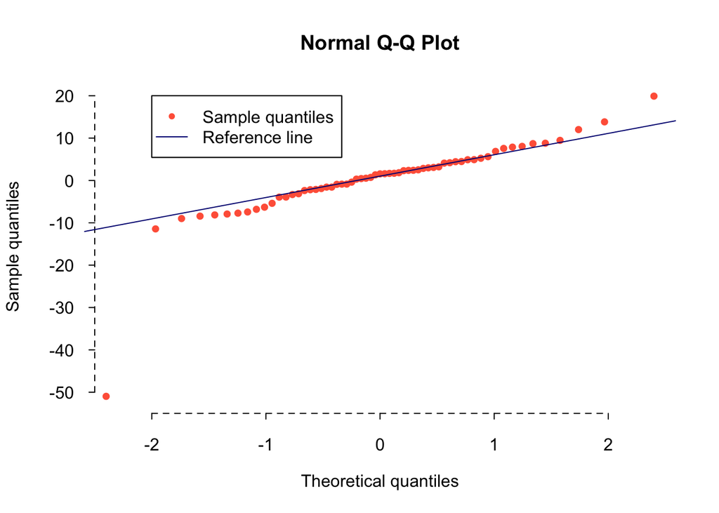

```r
qqnorm(R_ARR, pch=20, cex=1.2, col='tomato', axes=F,
                                   xlab='Theoretical quantiles',
                                  ylab='Sample quantiles')
axis(1, pos=-55, col='black', lty=2)
axis(2, pos=-2.5, las=T, col='black', lty=2)
qqline(R_ARR, col = 'navy')
legend(-2, 20, legend=c('Sample quantiles', 'Reference line'),
        pch=c(20, NA), lty=c(NA, 1), cex=c(1, 1),
                     col=c('tomato', 'navy'), text.col=c('black', 'black'))
```

The qqplot shows that the tails are fatter than the normal assumption, a characteristic that we observed in the histogram too.  
In this case *qqnorm* is a high level plotting function, while *axis*, *qqline* and *legend* are low level plottig functions.  
Note that this plot has custom axes: set *axes=F* inside *qqnorm* and then add your custom axes with *axis*.  
*pch* and *cex* allow to set the plotted symbol and its scale, respectively.  
With *legend* you can set almost every aspect of your legend, but you have to respect the order of the variables to get a correct result.

To proceed, the normality of R_ARR (ARMOUR’s excess returns) must be assumed. Pay attention when you are assuming normality though, it may lead to dramatically wrong results, in particular when you are dealing with risk management.

#### Create a new dataframe with all the useful data

Before continuing it’s better to organize the data in a unique dataframe, more specifically an object of class ‘zoo’ (‘xts’). At the same moment, the observations of Dec 2015 are removed because they are only missing values (NA’s). The observations of Jan 2021 are removed too. Then, the new dataframe contains only observations for the period Jan 2016 - Dec 2020.

```r
all.dataframe <- data.frame(R_ARR, R_MKT, SMB, HML)
all.dataframe <- xts(all.dataframe, order.by = date, frequency = 12)
all.dataframe <- all.dataframe['2016-01-01/2020-12-01']
```

There are three passages to get this job done (look at the code above):  
1. Create an object of class ‘data.frame’ with the *data.frame* function;  
2. Convert the ‘data.frame’ class object into a ‘zoo’ class object with the function *xts*. You have to specify a vector of dates (with *order.by*), that’s an object of class POSIXct, POSIXt;  
3. Subset the object according to the desired period.

In this way you obtain a dataframe with all the relevant variables of the regressions (R_ARR, R_MKT, SMB, HML) in a format that’s useful for the analysis (it’s a ‘zoo’ class object).

A confirm that NA’s are deleted can be found with this chunk:

```r
apply(all.dataframe, MARGIN = 2, function(x) sum(is.na(x)))
```

```
## R_ARR R_MKT   SMB   HML
##     0     0     0     0
```

The apply function applies a function to the margins of a matrix. It can work with a dataframe like ‘all.dataframe’ too.  
*MARGIN=2* means that you want to apply the function to the columns of the dataframe. The function applied is *function(x) sum(is.na(x))*.  
The output describes the number of NA’s of each column (variable): all variables have zero NA’s.

#### Check the linear relationship between the regressand (R_ARR) and each of the regressors (R_MKT, SMB, HML) of the models fitted

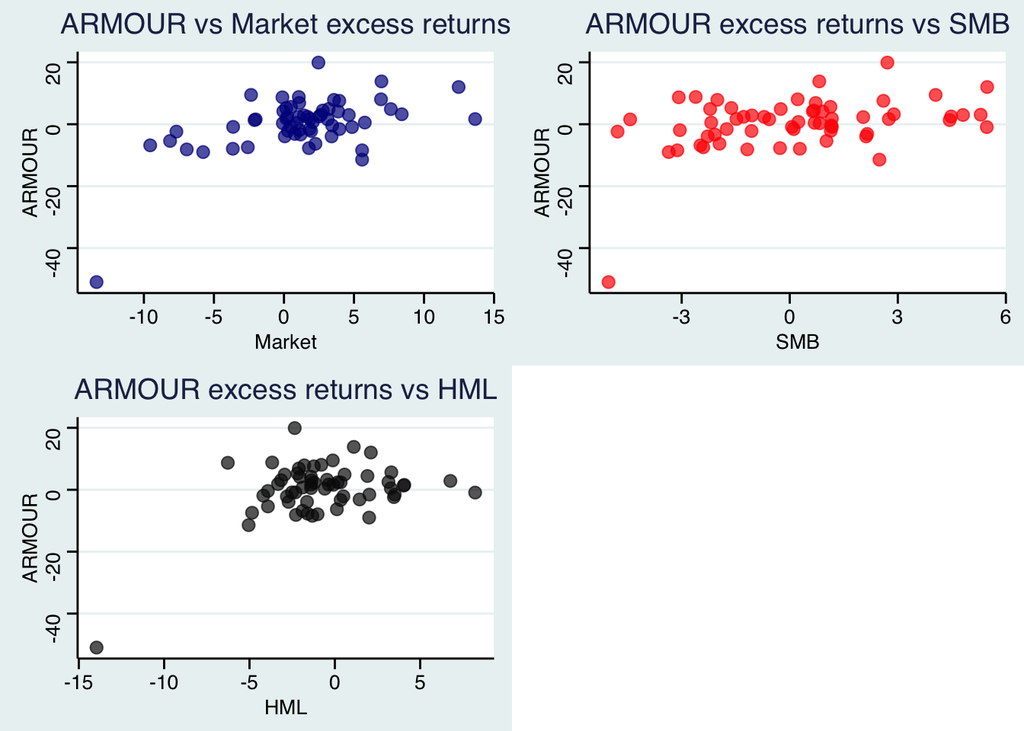

```r
lindep1 <- ggplot(data=all.dataframe, mapping=aes(x=R_MKT, y=R_ARR)) +
              geom_point(size=4, shape=20, col='blue4', alpha=0.7)+
    ggtitle('ARMOUR vs Market excess returns')+
                         xlab('Market') + ylab('ARMOUR')+
                                           theme_stata()

lindep2 <- ggplot(data=all.dataframe, mapping=aes(x=SMB, y=R_ARR)) +
  geom_point(size=4, shape=20, col='red', alpha=0.7)+
  ggtitle('ARMOUR excess returns vs SMB')+
  xlab('SMB') + ylab('ARMOUR')+
  theme_stata()

lindep3 <- ggplot(data=all.dataframe, mapping=aes(x=HML, y=R_ARR)) +
  geom_point(size=4, shape=20, col='grey4', alpha=0.7)+
  ggtitle('ARMOUR excess returns vs HML')+
  xlab('HML') + ylab('ARMOUR')+
  theme_stata()

grid.arrange(lindep1, lindep2, lindep3, ncol=2)
```

The code displayed above produces a plot with four figure regions, but only three of them include a plot. The function used to get a plot like this is *grid.arrange* and you have to name all the plot objects to be arranged.

The package used here is *ggplot2* from the tidverse.  
Basically, this package allows to build plots with a code syntax based on layers.  
You have to initialize the graphical page with the *ggplot* function and then add the plot components inside each layer of code. For example, the *geom_point* function allows to plot the variables specified in *ggplot* as points producing a scatterplot.

The linear relationship is assumed between R_ARR (the regressand, ARMOUR’s excess returns) and each of the regressors (R_MKT -market excess returns-, HML and SMB), on the basis of the graphical evidence.

#### OLS approach - Single-index and Fama-French models regression

The Single-Index model implies the regression of ARMOUR’s excess returns (R_ARR) on the market excess returns (R_MKT). The regression coefficient found is called ‘beta’ and the intercept is called ‘alpha’.  
Alpha is the abnormal stock’s return while beta is the stock’s responsiveness to the market return.  
The function *lm* of the R package *stats* allows to fit any linear model, while *summary* returns the output.

```r
s.i.OLS <- lm(R_ARR~R_MKT, data=all.dataframe)
summary(s.i.OLS)
```

```
##
## Call:
## lm(formula = R_ARR ~ R_MKT, data = all.dataframe)
##
## Residuals:
##     Min      1Q  Median      3Q     Max
## -35.824  -2.866   0.771   4.283  18.499
##
## Coefficients:
##             Estimate Std. Error t value Pr(>|t|)
## (Intercept)  -1.1585     1.0167  -1.139    0.259
## R_MKT         1.0458     0.2107   4.964  6.4e-06 ***
## ---
## Signif. codes:  0 '***' 0.001 '**' 0.01 '*' 0.05 '.' 0.1 ' ' 1
##
## Residual standard error: 7.59 on 58 degrees of freedom
## Multiple R-squared:  0.2982, Adjusted R-squared:  0.2861
## F-statistic: 24.64 on 1 and 58 DF,  p-value: 6.404e-06
```

The intercept (alpha) isn’t significant, while the beta is significant and equal to 1.0458 (considering the period Jan 2016-Dec 2020). The R-squared equals 0.2982.  
The level of beta found is almost equal to the beta of the market (1 by construction). This means that ARMOUR’s stock should follow closely the market portfolio movements.

The Fama-French Three-Factor model is a step forward with respect to the Single-Index model. It adds two more regressors: SMB and HML. These variables, as explained in the introducion paragraph, proxy for the extra-market risk exposure of the stock, difficult to observe. SMB and HML are included in the F-F model because, on empirical ground, they seem to proxy for exposure to systematic (non-diversifiable) risk.  
If the regression coefficients (beta) of HML and SMB are found significant, the risk factors behind these proxies have influenced past returns.  
The sensitivity to changes of the proxied risk factors is again represented by the correspondent beta coefficient. If the beta of SMB is found significant and positive, for example, some non-diversifiable (systematic) extra-market risk exposure, linked with the small capitalization of the firm, is detected. On the other hand, a high HML beta signals a risk exposure linked with the small P/E ratio of the (value) company.

The linear model is fitted with *lm*:

```r
FF.OLS <- lm(R_ARR~R_MKT+SMB+HML, data=all.dataframe)
summary(FF.OLS)
```

```
##
## Call:
## lm(formula = R_ARR ~ R_MKT + SMB + HML, data = all.dataframe)
##
## Residuals:
##      Min       1Q   Median       3Q      Max
## -26.5493  -3.4478   0.5473   3.3075  18.9864
##
## Coefficients:
##             Estimate Std. Error t value Pr(>|t|)
## (Intercept)  -0.2972     0.9963  -0.298 0.766591
## R_MKT         0.8066     0.2235   3.610 0.000655 ***
## SMB           0.4175     0.4060   1.028 0.308232
## HML           0.8049     0.2934   2.743 0.008160 **
## ---
## Signif. codes:  0 '***' 0.001 '**' 0.01 '*' 0.05 '.' 0.1 ' ' 1
##
## Residual standard error: 7.127 on 56 degrees of freedom
## Multiple R-squared:  0.4024, Adjusted R-squared:  0.3704
## F-statistic: 12.57 on 3 and 56 DF,  p-value: 2.156e-06
```

The intercept and SMB coefficient aren’t significant.  
The market beta and the HML beta are significant, positive and equal to 0.80.  
The R-squared is improved from 0.2982 to 0.4024.  
Some extra-market risk exposure, linked with the fact that the firm is a ‘value’ company with a low P/E ratio, is detected and this has improved the regression results with respect to the Single-Index model.

#### Regression function and looping

You may want to perform the regression analysis focusing only on a specified year: one way to do this is to build a function which fit the regression model only to the data belonging to the year selected.

I need a dataframe with all the data to fit the Fama-French model plus a variable column with only the year of each observation.

```r
data.function<- data.frame(R_ARR, R_MKT, SMB, HML)
year <- format(date, format='%Y')
data.function <- data.function %>% add_column(year)
data.function <- data.function %>% filter(year > 2015 & year<2021)
```

*format* extracts a vector with only the year values from the vector with the dates (‘date’). This ‘year’ vector is added to a dataframe which includes all the data needed to perform the regression analysis of the Fama-French model.  
The package ‘tibble’ is used to manage the dataframes here. The pipe operator ’ %>% ’ is a characteristic of the tidyverse code syntax.

The chunk of code below is an example of such a regression function.  
It fits the Fama-French model but it can be simplified to fit the Single-Index model too.  
You have to specify only the year as argument.

```r
reg.function <- function(reg.Year) {

  reg.model = lm(R_ARR ~., data = data.function %>% filter(year == reg.Year)
                                                            %>% select(-year))

   return( data.frame ( year=reg.Year,
             RSquared = summary(reg.model)$r.squared,
              Beta_mkt = summary(reg.model)$coefficients[2,1],
          Beta_SMB = summary(reg.model)$coefficients[3,1],
        Beta_HML = summary(reg.model)$coefficients[4,1]     )  )
                                                                     }
```

This function returns a dataframe with the year, the R squared and all the betas.  
The *dplyr* package from the tydiverse (specifically the *filter* function) is used to subset the dataframe according to the year selected for the regression. *select(-year)* is needed to avoid to use the year column as a regressor.

```r
reg.function(2016)
```

```
##   year  RSquared Beta_mkt   Beta_SMB   Beta_HML
## 1 2016 0.4327383 1.485001 -0.5118867 -0.3128154
```

If you want to run the Fama-French model regression to every year and store the results in a dataframe, you can use the regression function in loop. The *purrr* package from the Tidyverse can do the job.

```r
reg.dataframe.short <- purrr::map_dfr(
                      .x = unique(data.function$year),
                          .f=reg.function)
```

The function *map* from the *purrr* package allows to apply a specified function to each element of a list or atomic vector.  
You have to specify the mapping according to which the function is applied. In this case the mapping is given by *unique(data.function$year)*, which returns 2016, 2017, 2018, 2019, 2020. This means that you want to apply the regression function to the data year by year.

The result is the following:

```r
reg.dataframe.short
```

```
##   year  RSquared  Beta_mkt   Beta_SMB   Beta_HML
## 1 2016 0.4327383 1.4850013 -0.5118867 -0.3128154
## 2 2017 0.2193311 0.7431213  0.4308432 -1.3488465
## 3 2018 0.5440170 0.2765407  1.3974820  1.5970141
## 4 2019 0.6835033 0.8519283  0.1386388  0.4295855
## 5 2020 0.6341564 0.6719036 -0.8479346  2.7591451
```

#### Diagnostic of the regression residuals (Single-Index and Fama-French models)

Define the residuals time series for first:

```r
res_s.i <- window(s.i.OLS$residuals) # single index model residuals
res_FF <- window(FF.OLS$residuals) # FF three factor model residuals

res_s.i <- ts(res_s.i, start=c(2016, 1), end=c(2020, 12), frequency = 12)
res_FF <- ts(res_FF, start=c(2016, 1), end=c(2020, 12), frequency = 12)
```

##### Normality of the residuals

Are the residuals of the two regressions (Single-Index and Fama-French) normally distributed?

Adjusted Jarque-Bera test for normality:

```r
ajb.norm.test(res_s.i)
ajb.norm.test(res_FF)
```

```
##
##  Adjusted Jarque-Bera test for normality
##
## data:  res_s.i
## AJB = 217, p-value < 2.2e-16
##
##
##  Adjusted Jarque-Bera test for normality
##
## data:  res_FF
## AJB = 35.605, p-value = 0.001
```

The test rejects for both assuming an alpha level (significance test) of 0.05. The residuals of the two models aren’t normally distributed.

A qq-plot will reveal the nature of the deviation from normality. Here is computed only the qq-plot for the Fama-French residuals.

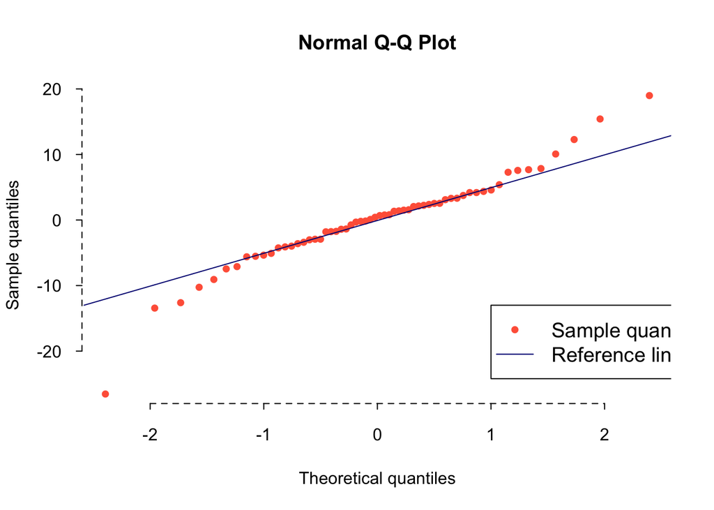

```r
qqnorm(res_FF, pch=20, cex=1.2, col='tomato', axes=F,
       xlab='Theoretical quantiles',
       ylab='Sample quantiles')
axis(1, pos=-28, col='black', lty=2)
axis(2, pos=-2.6, col='black', lty=2, las=T)
qqline(res_FF, col = 'navy')
legend(1, -13, legend=c('Sample quantiles', 'Reference line'),
       pch=c(20, NA), lty=c(NA, 1), cex=1.2,
       col=c('tomato', 'navy') , text.col = c('black', 'black'))
```

Analyzing the qq-plot it’s clear that fat tails are still persistent.

##### Homoskedasticity of the residuals

Breush-Pagan test for heteroskedasticity (H0:homoskedasticity, alpha level = 0.05).

```r
bptest(s.i.OLS)
bptest(FF.OLS)
```

```
##
##  studentized Breusch-Pagan test
##
## data:  s.i.OLS
## BP = 6.6514, df = 1, p-value = 0.009908
##
##
##  studentized Breusch-Pagan test
##
## data:  FF.OLS
## BP = 16.302, df = 3, p-value = 0.0009834
```

H0 rejected in both models: detected heteroskedastic residuals.

ncv test for heteroskedasticity (H0:homoskedasticity, alpha level = 0.05).

```r
ncvTest(s.i.OLS)
```

```
## Non-constant Variance Score Test
## Variance formula: ~ fitted.values
## Chisquare = 31.55482, Df = 1, p = 1.9389e-08
```

```r
ncvTest(FF.OLS)
```

```
## Non-constant Variance Score Test
## Variance formula: ~ fitted.values
## Chisquare = 28.8015, Df = 1, p = 8.0189e-08
```

The ncv test detects heteroskedasticity in both model residuals too.

##### Autocorrelation of the residuals

Durbin-Watson test (H0: no autocorrelation, alpha level = 0.05).

```r
durbinWatsonTest(s.i.OLS)
```

```
##  lag Autocorrelation D-W Statistic p-value
##    1      0.07061129      1.857664   0.524
##  Alternative hypothesis: rho != 0
```

```r
durbinWatsonTest(FF.OLS)
```

```
##  lag Autocorrelation D-W Statistic p-value
##    1      0.04196389      1.909055   0.682
##  Alternative hypothesis: rho != 0
```

The test doesn’t reject H0: no autocorrelation is detected in both model residuals.

Breusch-Godfrey test (H0: no autocorrelation, alpha=0.05).

```r
bgtest(s.i.OLS)
bgtest(FF.OLS)
```

```
##
##  Breusch-Godfrey test for serial correlation of order up to 1
##
## data:  s.i.OLS
## LM test = 0.31112, df = 1, p-value = 0.577
##
##
##  Breusch-Godfrey test for serial correlation of order up to 1
##
## data:  FF.OLS
## LM test = 0.1129, df = 1, p-value = 0.7369
```

The B-G test doesn’t reject too.

##### Stationarity of the residuals

```r
adf.test(res_s.i)
```

```
## Augmented Dickey-Fuller Test
## alternative: stationary
##
## Type 1: no drift no trend
##      lag   ADF p.value
## [1,]   0 -7.10    0.01
## [2,]   1 -5.58    0.01
## [3,]   2 -5.39    0.01
## [4,]   3 -4.07    0.01
## Type 2: with drift no trend
##      lag   ADF p.value
## [1,]   0 -7.04    0.01
## [2,]   1 -5.53    0.01
## [3,]   2 -5.34    0.01
## [4,]   3 -4.04    0.01
## Type 3: with drift and trend
##      lag   ADF p.value
## [1,]   0 -7.20    0.01
## [2,]   1 -5.75    0.01
## [3,]   2 -5.63    0.01
## [4,]   3 -4.36    0.01
## ----
## Note: in fact, p.value = 0.01 means p.value <= 0.01
```

```r
adf.test(res_FF)
```

```
## Augmented Dickey-Fuller Test
## alternative: stationary
##
## Type 1: no drift no trend
##      lag   ADF p.value
## [1,]   0 -7.32    0.01
## [2,]   1 -6.26    0.01
## [3,]   2 -5.46    0.01
## [4,]   3 -5.02    0.01
## Type 2: with drift no trend
##      lag   ADF p.value
## [1,]   0 -7.26    0.01
## [2,]   1 -6.20    0.01
## [3,]   2 -5.41    0.01
## [4,]   3 -4.97    0.01
## Type 3: with drift and trend
##      lag   ADF p.value
## [1,]   0 -7.25    0.01
## [2,]   1 -6.22    0.01
## [3,]   2 -5.41    0.01
## [4,]   3 -5.03    0.01
## ----
## Note: in fact, p.value = 0.01 means p.value <= 0.01
```

H0 (unit root) rejected: in both models residuals are stationary.

Conclusions:  
- both models display heteroskedastic and not autocorrelated residuals;  
- both have stationary residuals with fat tails, but normality is assumned.

At least theoretically, the regression results may be distorted due to the heteroskedasticity problem.

#### Plotting the OLS regression results

##### Single-Index model

The Single-Index model regression is plotted using different packages: the R ‘base’ packages and the *ggplot2* package from the tidyverse.

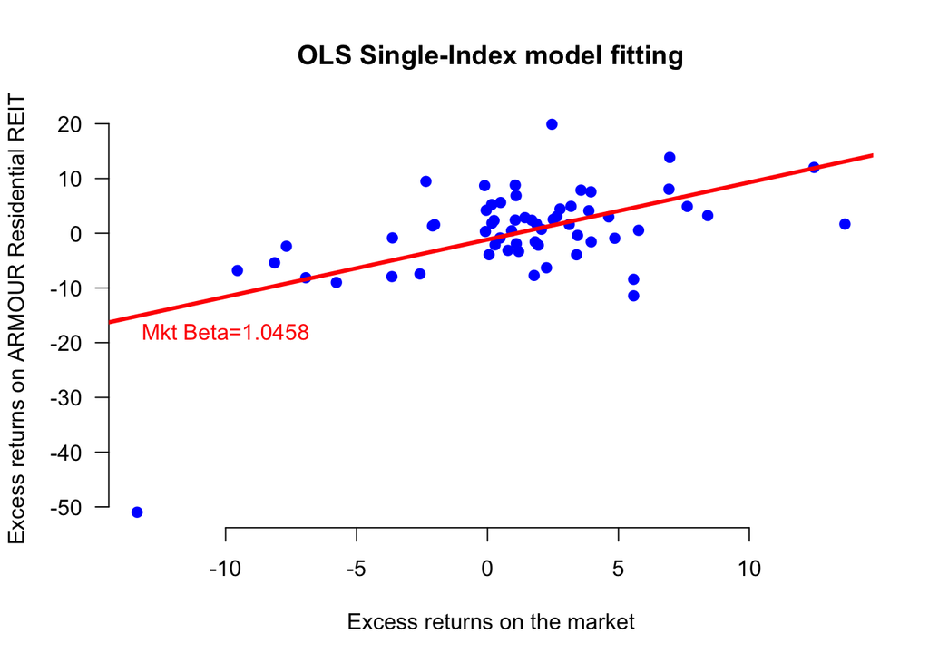

```r
plot(R_ARR ~ R_MKT, data=all.dataframe,
    main='OLS Single-Index model fitting',
           xlab='Excess returns on the market',
             ylab= 'Excess returns on ARMOUR Residential REIT',
                    pch=20, cex=1.5, col='blue',
                                        axes=F)
axis(1, lty='solid', col='grey4')
axis(2, lty='solid', col='grey4', las=T)
abline(s.i.OLS, col='red', lty=1, lwd=3)
text(x=-10, y=-18, 'Mkt Beta=1.0458', col = 'red')
```

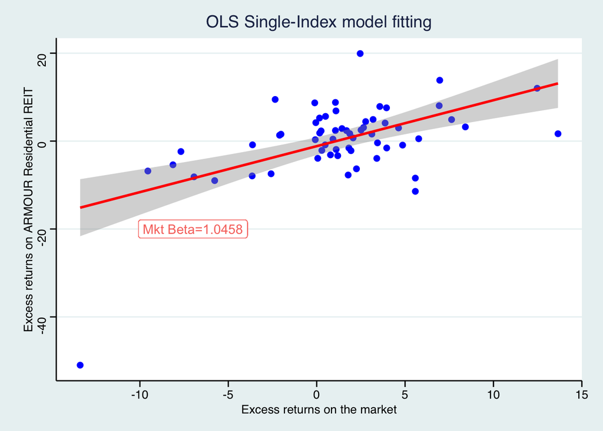

```r
ggplot(data=all.dataframe, mapping=aes( x = R_MKT, y = R_ARR )) +
  geom_point(col='blue', cex=2) +
  stat_smooth(method = 'lm', col = 'red', lwd=1)+
  xlab('Excess returns on the market') +
  ylab('Excess returns on ARMOUR Residential REIT')+
  ggtitle('OLS Single-Index model fitting')+
  geom_label(mapping=aes(x=-7, y=-20, label='Mkt Beta=1.0458', col='red'))+
  theme_stata()+
  theme(legend.position = 'none')
```

##### Fama-French Three-Factor Model

The regression results are plotted, again, with the R ‘base’ packages and with *ggplot*.

Here’s the result.

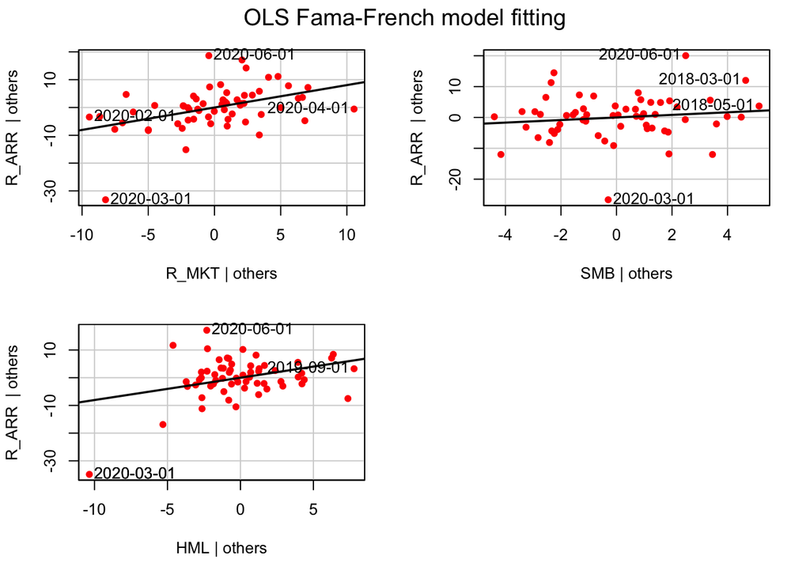

```r
avPlots(FF.OLS, layout=c(2,2), main='OLS Fama-French model fitting' ,
                     col='red', col.lines='grey2', lwd=1.8, pch=20, cex=1.2,
                        grid=T)
```

```r
par(mfrow=c(1,1))
```

The function *avPlots* from the *car* package provides a very simple tool to plot regressions with more than two regressors.

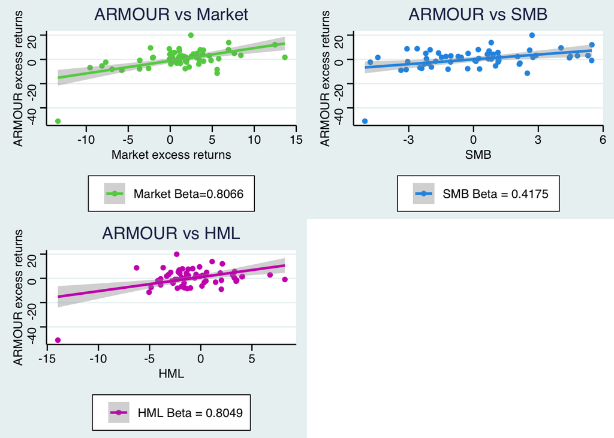

```r
Plot1 <- ggplot(data=all.dataframe, aes(x=R_MKT, y=R_ARR,
                                         col='Market Beta=0.8066 '))+
        geom_point()+
        stat_smooth(method='lm', lwd=1, se=T)+
        ggtitle('ARMOUR vs Market')+ xlab('Market excess returns')+
        ylab('ARMOUR excess returns')+
        theme_stata()+
        labs(colour='')+
        scale_color_manual(values=3)

Plot2 <-   ggplot(data=all.dataframe, aes(x=SMB, y=R_ARR,
                                           col='SMB Beta = 0.4175 '))+
          geom_point()+
          stat_smooth(method='lm', lwd=1, se=T) +
          ggtitle('ARMOUR vs SMB')+ xlab('SMB')+
          ylab('ARMOUR excess returns')+
          theme_stata()+
          labs(colour='')+
          scale_color_manual(values=4)

Plot3 <-   ggplot(data=all.dataframe, aes(x=HML, y=R_ARR,
                                           col='HML Beta = 0.8049'))+
           geom_point()+
           stat_smooth(method='lm', lwd=1, se=T)+
             ggtitle('ARMOUR vs HML') + xlab('HML')+
             ylab('ARMOUR excess returns')+
            theme_stata()+
            labs(colour='')+
            scale_color_manual(values=6)

grid.arrange(Plot1, Plot2, Plot3, ncol=2)
```

*grid.arrange* from the *gridExtra* package is used again to set four figure regions in the plotting space.

##### Residuals plotting

The last plot of this section depicts the residuals of the two models and is coded with the R ‘base’ packages.

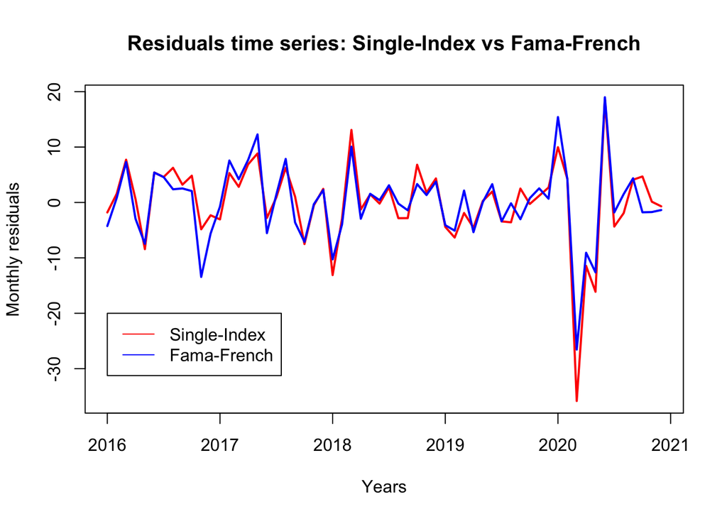

```r
ts.plot(res_s.i, res_FF, col=c('red', 'blue'), lty=c(1,1), lwd=c(2,2),
        main='Residuals time series: Single-Index vs Fama-French',
        xlab='Years', ylab='Monthly residuals')
legend(x=2016, y=-20, legend=c('Single-Index', 'Fama-French'), lty =c(1,1),
                                                   col=c('red', 'blue') )
```

## Conclusions

This paper explained how to use the R software to analyze the stock returns of a company. Among the packages presented, some belong to the tidyverse: it’s a bundle of packages which function with slighly different code syntax with respect to the R ‘base’ packages.

Here, some conclusions are drown.

ARMOUR’s excess returns, in the period January 2016 - December 2020, display a market beta of 1.046 according to the Single-Index model and a white noise structure. The company’s returns are characterized by fat tails, but this is not a surprise.  
The Fama-French model suggests that ARMOUR is exposed to extra-market risk factors proxied by the HML variable.  
During the COVID-19 pandemic outbreak period the data display a volatility cluster and a whopping negative return of -50.98%, followed by a slow increasing of stock prices.

## Bibiliography and sitography

Bodie, Kane, Marcus – Investments, 2018;  
The R project for statistical computing - https://www.r-project.org/.